# 2 Univariate data

Statistics involves the study of data. A data set can be a single value, or *scalar*, but more commonly is a collection of values. This chapter covers the basic containers used in `Julia` to store and manipulate data sets for a single variable in statistics. In addition it shows some well-known summaries of a single variable.

## 2.1 Data vectors

`Julia` offers several containers for storing ordered data, such as in a data set $x_1, x_2, \dots, x_n$.

We consider this data on the number of whale beachings in a certain area by year during a decade:

```
74 122 235 111 292 111 211 133 156 79
```

As the data in a data set is typically of the same type (integer here, or character, number, …) and may be quite large a vector is a natural choice for storage in `Julia`.

Vectors are created using square brackets with entries separated by commas. Storing the data in a vector and assigning to a variable, `whale`, is then done with:

```julia
whale = [74, 122, 235, 111, 292, 111, 211, 133, 156, 79]
```

```
10-element Vector{Int64}:
  74
 122
 235
 111
 292
 111
 211
 133
 156
  79
```

Without using commas in the construction, a matrix is created:

```julia
whale_matrix = [74 122 235 111 292 111 211 133 156 79]
```

```
1×10 Matrix{Int64}:
 74  122  235  111  292  111  211  133  156  79
```

**Space-saving measure**

For purposes of printing only, we use `show` or the trailing `|> show` (which uses the chaining operation to call the `show` function) in the following to format how a vector is printed. This is only a vertical-space-saving measure and wouldn’t normally be done when interacting with `Julia`.[^1]

```julia
show(whale)
```

```
[74, 122, 235, 111, 292, 111, 211, 133, 156, 79]
```

Internally a vector is a $1$-dimensional array, a matrix a $2$-dimensional array. `Julia` has a general $N$-dimensional array type that these are specializations of. For a matrix, one uses space to separate row elements and semicolons to separate rows. Vectors are useful for storing data; matrices can be used to store data, as will be seen through example, but are widely used to represent mathematical values, as they have an associated algebra that can compactly represent many operations (we will see a data frame is more idiomatic for storing rectangular data); arrays are not used in our discussion.

As seen in the output above, `Julia` prints the size and *element type* of a vector. In this case, a vector of integers (`Int64`). The constructor (`[]`) will promote values to a common type, which may be `Any`, a catch all type.

Vectors have a length, found by `length`, which in this case is the number of data points, often labeled $n$. More generally, arrays have a `size`:

```julia
length(whale), size(whale)
```

```
(10, (10,))
```

The size is returned as a `tuple`, in this case with just 1 element, as vectors are $1$ dimensional.

The `length` function is a reduction, returning a summary of a vector. Similarly, `sum` will add the elements, returning a number. Here we see how to compute the mean:

```julia
sum(whale) / length(whale)
```

```
152.4
```

The `mean` function is not part of base `Julia`. It can be found in the `Statistics` package, which comes bundled with `Julia`, but we prefer to use the add-on `StatsBase` package:

```julia
using StatsBase
mean(whale)
```

```
152.4
```

### 2.1.1 Missing values

`Julia` uses `missing` to represent missing values. For example, data on the cost of a hip replacement at various hospitals was found from their websites and is given by:

```
10500, 45000, 74100, unavailable, 83500,
86000, 38200, unavailable, 44300, 12500,
55700, 43900, 71900, unavailable, 62000
```

When the cost could not be identified, it was labeled “unavailable.” We replace the colloquial “unavailable” with the special value `missing` and enter the values into a vector:

```julia
hip_cost = [10500, 45000, 74100, missing, 83500, 86000, 38200, missing,
            44300, 12500, 55700, 43900, 71900, missing, 62000]
hip_cost |> permutedims
```

```
1×15 reshape(::Vector{Union{Missing, Int64}}, 1, 15) with eltype Union{Missing, Int64}:
 10500  45000  74100  missing  83500  …  55700  43900  71900  missing  62000
```

We highlight that the type of element in `hip_cost` is `Union{Missing, Int64}`, a type that allows an element to be either an integer or a `missing` element.

The `missing` value propagates through computations:

```julia
sum(hip_cost)
```

```
missing
```

In particular, all of these combinations with `missing` yield `missing`, as they should—if data is not available, combinations based on that data are still not available:

```julia
1 + missing, 1 - missing, 1*missing, 1/missing, missing^2, missing == true
```

```
(missing, missing, missing, missing, missing, missing)
```

**Also nothing and something**

In `Julia` there is also `nothing`. The semantics are a bit different, and `missing` is the designed choice for data. (The `nothing` value is useful for general programming purposes.) For floating point values, there is also `NaN`, or not a number. This too is often used as a sentinel value, to indicate missingness, though `missing` is idiomatic. The `something` function is used to skip over its arguments until a non-`nothing` value is found. The `coalesce` function does a similar thing with `missing` values.

To work with missing data, it can be removed or skipped over. The `skipmissing` function provides a wrapper around an object which when iterated over, will skip the missing values. For example:

```julia
sum(skipmissing(hip_cost))
```

```
627600
```

The `sum` function iterates over the values in the container it is passed to reduce them to a value, `mean` is similar and works with `skipmissing` in an identical manner:

```julia
mean(skipmissing(hip_cost))
```

```
52300.0
```

(Which is helpful, as `length`, used above to compute a mean, does not compose with `skipmissing`.)

### 2.1.2 Names (named tuples)

It may be natural to assign the year of measurement to the values in `whale`, but vectors, as defined in base `Julia`, do not allow names as an attribute. (There are external packages that allow this, e.g. `NamedArrays`, which arise in our discussion of contingency tables.) If names are important, `Julia` provides a named tuple type, which builds on the basic tuple type.

While vectors are collections of *homogeneous* values, tuples are collections of *heterogeneous* values. Tuples are constructed with commas, and typically parentheses to delimit the commas:[^2]

```julia
whale = (74, 122, 235, 111, 292, 111, 211, 133, 156, 79)
```

```
(74, 122, 235, 111, 292, 111, 211, 133, 156, 79)
```

One-element tuples are distinguished by using a trailing command and parentheses:

```julia
a_lone_whale = (101,)
```

```
(101,)
```

For the many purposes, tuples can be exchanged for vectors, as both are iterable[^3]:

```julia
sum(whale), mean(whale), length(whale)
```

```
(1524, 152.4, 10)
```

Unlike vectors, but like numbers, tuples can not be *modified* after construction. This allows tuples to be quite useful—and performant—for programming purposes.

Tuples can also have names. The basic construction uses “key=value” pairs:

```julia
test_scores = (Alice = 87, Bob = 72, Shirley = 99)
```

```
(Alice = 87, Bob = 72, Shirley = 99)
```

The names are not quoted, and are stored internally as a tuple of symbols. Extra effort is necessary to create names with spaces or number. In the following example we show that `var"..."` is useful to create more complicated symbols[^4]:

```julia
children = (var"X Æ A-Xii" = 1,
            var"Vivian Jenna Wilson" = 2,
            var"Exa Dark Sideræl" = 3)
```

```
(var"X Æ A-Xii" = 1, var"Vivian Jenna Wilson" = 2, var"Exa Dark Sideræl" = 3)
```

The above also shows that [Unicode](https://docs.julialang.org/en/v1/manual/unicode-input/) values are easily used within `Julia` in strings or as identifiers.

Named tuples can also have their “names” attached via parsing, through a syntax similar to keyword arguments of functions, as identifiers [imply names](https://docs.julialang.org/en/v1/base/base/#Special-Types):

```julia
a = [1,2]; b = [3,4]
(; a, b)  # same as (a=a, b=b)
```

```
(a = [1, 2], b = [3, 4])
```

This gives several different ways to construct $1$-element named tuples, where something is done to disambiguate the use of enclosing parentheses:

```julia
(; a), (; a=a), (; :a => a), (a=a, )
```

```
((a = [1, 2],), (a = [1, 2],), (a = [1, 2],), (a = [1, 2],))
```

Named tuples can have their values accessed by name using `getproperty`, which has a `.` for convenient syntax:

```julia
test_scores.Alice
```

```
87
```

The generic function `keys` will return the names (“keys” are used to look up a value) and `values` will extract the values.

Named tuples being both named and heterogeneous are a natural container for collecting data on several different variables for a single case, as will be seen in the discussion on tabular data.

#### Associative arrays

Abstractly, an *associative array* is a container for storing (key,value) pairs. `Julia` has the notation `key => value` for representing a *pair*. A named tuple is an immutable associative array where the keys are symbols. A *dictionary* is a more general *mutable* type with the keys being arbitrary (numbers, strings, symbols, …). There are various implementations of an `AbstractDict`, the `Dict` constructor being the most commonly used, though the one provided in the `Dictionaries` package will be seen. As with a named tuple, the keys are returned by `keys`, the values by `values`, and pairs of (key/value)s by `pairs`.

### 2.1.3 Indexing

The elements of a vector, like a data set, are indexed. For vectors Julia uses one-based indexing[^5]. The `whale` data, as defined, has $10$ elements, we can get the third, fourth, and sixth with:

```julia
whale = [74, 122, 235, 111, 292, 111, 211, 133, 156, 79]
whale[3], whale[4], whale[6]
```

```
(235, 111, 111)
```

The above uses three function calls, and displays as a tuple does. (Since the commas produce a tuple.)

To retrieve these same values in a single call, we can pass a vector of indices:

```julia
whale[ [3,4,6] ]
```

```
3-element Vector{Int64}:
 235
 111
 111
```

The `end` keyword refers to the last index of a collection. Similarly, `begin` refers to the first index inside the square brackets.

```julia
whale[end], whale[begin]
```

```
(79, 74)
```

These values allow simple arithmetic. Here we see how to trim off the first and last through indexing[^6]:

```julia
whale[begin+1:end-1] |> show
```

```
[122, 235, 111, 292, 111, 211, 133, 156]
```

The colon, `:`, refers to all indices in a vector; `whale[:]` will return a copy of the data in `whale`.

**Indexing with a container of values**

The range `1:1` specifies the value `1`, as does just `1`, but for indexing the two are different:

```julia
whale[1], whale[1:1]
```

```
(74, [74])
```

The design is indexing by a scalar—like `1`—can drop dimensions (the vector becomes a scalar), whereas indexing by a container—like `1:1` or, say, `[1]`—does not drop dimensions. The documentation for indexing of an array has: “If all the indices are scalars, then the result, `X`, is a single element from the array, `A`. Otherwise, `X` is an array with the same number of dimensions as the sum of the dimensionalities of all the indices.”

#### Views

The extraction of values from a vector, as above, necessitates the allocation of memory to store the copy of the values. When the data set is large, or is accessed many times, these allocations may be avoided using a “view” of the data. Views create a lazy reference to the underlying data in the array. The `view` function takes the object as its first argument, and indices for its remaining arguments[^7]:

```julia
view(whale, [3,4,6])
```

```
3-element view(::Vector{Int64}, [3, 4, 6]) with eltype Int64:
 235
 111
 111
```

The `end` and `begin` keywords do not work with `view`[^8]; the `lastindex` and `firstindex` functions do:

```julia
view(whale, firstindex(whale)+1:lastindex(whale)-1) |> show
```

```
[122, 235, 111, 292, 111, 211, 133, 156]
```

### 2.1.4 Assignment

The assignment

```julia
whale = [74, 122, 235, 111, 292, 111, 211, 133, 156, 79]
show(whale)
```

```
[74, 122, 235, 111, 292, 111, 211, 133, 156, 79]
```

binds the name `whale` to the *container* holding the $10$ numbers.

If we make another assignment, as in

```julia
whale_copy = whale
show(whale_copy)
```

```
[74, 122, 235, 111, 292, 111, 211, 133, 156, 79]
```

### 2.1.5 Modification

Data may need to be modified after read in or constructed, such as is done with data cleaning. As such, the values in the data vector may need to be reassigned. This is carried out by using the indexing notation on the left-hand side of an assignment:

```julia
whale[1] = 75
```

```
75
```

The value `75` is returned, as the *right-hand* side of an assignment is always the returned value. We can see that `whale` was modified:

```julia
whale[1], whale_copy[1]
```

```
(75, 75)
```

We also see that as `whale_copy` points to the same container, it too was modified.

**Mutation**

When a vector is passed to a function, if there is no copy made (as opposed to a simple naming), then changes to the vector in the function will effect the original vector as the container used in the body of the function isn’t changed. Functions which *modify* an argument that is passed to them (usually the first one) are *conventionally* named with a trailing `!`, though this has no semantic implication.

Multiple values can be assigned at once. For example, if the data was misarranged chronologically, we might have:

```julia
whale[ [1,2,3] ] = [235, 74, 122]
show(whale)
```

```
[235, 74, 122, 111, 292, 111, 211, 133, 156, 79]
```

The above modified the original container, so these changes would also be reflected in `whale_copy`.

`Julia` does not recycle values to be assigned by default, where recycling involves some rules where the space referenced on the left-hand side of an assignment does not match in size the space needed to store the right-hand side of an assignment. *Broadcasted assignment* (cf. `?.=`) can produce a similar behavior. Broadcasted assignment expands the right-hand side to match the space expected on the left side (when possible) and then does the assignment. For example, if we wanted to use a sentinel value to indicate unknown data for the first 3 values, we might have:

```julia
whale[[1,2,3]] .= 999
show(whale)
```

```
[999, 999, 999, 111, 292, 111, 211, 133, 156, 79]
```

Notice, without the dot an error will be thrown

```julia
whale[[4,5,6]] = 999  # errors
```

```
ArgumentError: indexed assignment with a single value to possibly many locations is not supported; perhaps use broadcasting `.=` instead?
Stacktrace:
 [1] setindex_shape_check(::Int64, ::Int64)
   @ Base ./indices.jl:276
 [2] _unsafe_setindex!(::IndexLinear, A::Vector{Int64}, x::Int64, I::Vector{Int64})
   @ Base ./multidimensional.jl:976
 [3] _setindex!
   @ ./multidimensional.jl:967 [inlined]
 [4] setindex!(A::Vector{Int64}, v::Int64, I::Vector{Int64})
   @ Base ./abstractarray.jl:1413
 [5] top-level scope
   @ ~/UsingJ/EDA/univariate-julia.qmd:356
```

The “recycling” above uses the left-hand side to identify the size needed. Broadcasted assignment also works with the entire collection. For example, the following command replaces the current data with the original data:

```julia
whale .= [74, 122, 235, 111, 292, 111, 211, 133, 156, 79]
show(whale)
```

```
[74, 122, 235, 111, 292, 111, 211, 133, 156, 79]
```

But `whale` is not a new object—as it would be without that dot—but rather, these values are placed into the container `whale` already refers to—which also is the container `whale_copy` points at:

```julia
show(whale_copy)
```

```
[74, 122, 235, 111, 292, 111, 211, 133, 156, 79]
```

This assignment avoids the needed allocation of more memory.

The use of `[:]` on the *left-hand side* also does in-place assignment[^9]. So unlike `whale = [...]` which *replaces* the container `whale` points at, this command reuses the container:

```julia
whale[:] = [74, 122, 235, 111, 292, 111, 211, 133, 156, 79]
show(whale)
```

```
[74, 122, 235, 111, 292, 111, 211, 133, 156, 79]
```

Table 2.1: Various indexing patterns.

[output not shown]

#### Vector size

A vector has a length which can not be changed during assignment. Attempting to assign to an index beyond the size will result in a `BoundsError`. To extend the size of a vector we can use the following generic functions:

- `push!(v, x)`: extend the vector `v` pushing `x` to the *last* value
- `pushfirst!(v, x)`: extend the vector `v` pushing `x` to the *first* value
- `append!(v, v1)`: append the entries in `v1` to the end of `v`
- `insert(v, i, x)`: insert `x` into `v` at index `i`, shifting as needed
- `vcat(v, v1)`: **v**ertically con**cat**enate `v` and `v1`. (Unlike `append!` this returns a new vector, so the type of the output will be recomputed).

The vector can also be shrunk. These generic functions for containers are useful:

- `pop!(v)`: remove *last* element from a vector; return element
- `popfirst!(v)`: remove *first* element from a vector; return element
- `deleteat!(v, i)`: remove *i*the element from a vector; returns vector
- `empty!(v)`: remove *all* elements from a vector

Again, the trailing `!` in a function name is a convention to indicate to the user that the function will mutate its arguments, conventionally its first one. That is, a function like `pop!(v)` does two things: it returns the last element and *also* shortens the vector `v` that is passed in.

#### Vectors have an element type

The assignment `whale = [74, 122, 235, ...]` assigns a container of a *specific* type to the variable `whale`. The `eltype(whale)` command will return this element type. Subsequent assignments to this container must contain values that can be *promoted* to that type, otherwise an error will be thrown.

For example, we can’t assign a fractional number of whales:

```julia
whale[1] = 74.5
```

```
InexactError: Int64(74.5)
Stacktrace:
 [1] Int64
   @ ./float.jl:994 [inlined]
 [2] convert
   @ ./number.jl:7 [inlined]
 [3] setindex!(A::Vector{Int64}, x::Float64, i::Int64)
   @ Base ./array.jl:987
 [4] top-level scope
   @ ~/UsingJ/EDA/univariate-julia.qmd:431
```

An `InexactError` is thrown because, `whale` is a vector of integers, and `74.5` can’t be automatically promoted to an integer (as `74.0` could be).

A similar thing happens if we attempt to assign `missing` to a value, as in `whale[1] = missing`. In this case, a `MethodError` is thrown, which comes from the attempt to “`convert`” `missing` into the underlying integer type.

The way to fix this is to create a new container that allows a wider type. For `Float64` values that can be achieved in the cumbersome manner of converting all the values to the wider type:

```julia
whale = convert(Vector{Float64}, whale)
whale[1] = 74.5
```

```
74.5
```

This assigns `whale` to a *new* container which accepts floating point values, and then reassigns the first one.

Though cumbersome, this is not typical usage, as the constructor used to create the data set will promote to a common type, so it would only matter when adjusting the initial values.

For the special case of assigning a *missing* value, the `allowmissing` function from the `DataFrames` package[^10] creates a vector with a type that allows—as well—missing values[^11]. Again, re-assignment is necessary:

```julia
using DataFrames
whale = allowmissing(whale)
whale[1] = missing
```

```
missing
```

#### Broadcasting

As seen, the functions `length` and `sum` are reductions—in this case, returning a single number, a scalar, from a vector of numbers. To compute a *sample standard deviation*, say, we follow the formula:

$$s = \sqrt{\frac{\sum_i (x_i - \bar{x})^2 }{n-1}}.$$

To do so we would need to:

- Subtract a scalar value, resulting for a reduction, from from each element of the data vector: ($x_i - \bar{x}$).
- Apply the squaring function to each element of this difference.
- Reduce the resulting data to a number through `sum`.
- Divide a number by another number and take the square root.

Embarking on this punch list with a naive attempt at the first – `whale - mean(whale)`—will fail.

The subtraction of a scalar value from a vector value is not defined, as `Julia` is not implicitly vectorized. Rather the user must be explicit. For this, the concept of broadcasting is useful. In this context, broadcasting will expand the scalar to match the size of the vector and then use vector subtraction to find the result. Broadcasting is done simply by adding a “.” (the dot) to the function. For infix operations like `-` this is *before* the operator:

```julia
whale = [74, 122, 235, 111, 292, 111, 211, 133, 156, 79]
whale .- mean(whale)  |> show
```

```
[-78.4, -30.400000000000006, 82.6, -41.400000000000006, 139.6, -41.400000000000006, 58.599999999999994, -19.400000000000006, 3.5999999999999943, -73.4]
```

We also would need to square these values. This could *also* be done by broadcasting `^`, as in:

```julia
(whale .- mean(whale)).^2  |> show
```

```
[6146.560000000001, 924.1600000000003, 6822.759999999999, 1713.9600000000005, 19488.16, 1713.9600000000005, 3433.959999999999, 376.36000000000024, 12.959999999999958, 5387.56]
```

To avoid having to use *too* many dots, it is typical to define a function for doing a scalar computation and broadcast that[^12]. An example will wait, but to illustrate the syntax, we can broadcast the `sqrt` function using a “.” after the function name and before the opening parentheses:

```julia
sqrt.(whale)  |> show
```

```
[8.602325267042627, 11.045361017187261, 15.329709716755891, 10.535653752852738, 17.08800749063506, 10.535653752852738, 14.52583904633395, 11.532562594670797, 12.489995996796797, 8.888194417315589]
```

Broadcasting works with functions of multiple arguments and multiple shapes.

The use of multiple shapes allows scalars and vectors to be broadcast over and is used in `whale .- mean(whale)`. With this, the standard deviation could be computed with:

```julia
sqrt( sum((whale .- mean(whale)).^2)/(length(whale) - 1) )
```

```
71.5078861229849
```

Vector and *row* vectors can also be broadcast over, So `[1,2] .+ [3,4]` does vector addition, `[1,2] .+ [3 4]` pads out the vector to a matrix, the row vector to a matrix, then adds entry-by-entry:

```julia
(v=[1,2], rv=[3 4], va = [1,2] .+ [3,4], ma = [1, 2] .+ [3 4], ck=[1 1; 2 2] + [3 4; 3 4])
```

```
(v = [1, 2], rv = [3 4], va = [4, 6], ma = [4 5; 5 6], ck = [4 5; 5 6])
```

This behavior may not be desirable. Some objects broadcast as scalars, others as containers. But there may be times where broadcasting as a container may be incorrect. To force a value to broadcast like a scalar, the value can be wrapped in `Ref`. That is `mean(whale)` is the same as `mean.(Ref(whale))` *but* `mean.(whale)` would broadcast `mean` over each element in `whale`. As `mean` for a single number is just that number, `mean.(whale)` would just be the same values.

## 2.2 Data types

An old [taxonomy](https://en.wikipedia.org/wiki/Statistical_data_type) of levels of measurement include nominal, ordinal, interval, and ratio; where nominal values have no rank; ordinal values have a rank, but no meaning is assigned to the difference between values; interval data has a meaning between differences but $0$ is arbitrary; and ratio has a meaningful zero, such as most numeric data. As data can easily be coded (explicitly or behind the scenes) with numbers, this keeps the different types distinct. However, for use with the computer, in particular `Julia` here, we see it also more sense to emphasize different aspects of the data related to the underlying type.

`Julia` has numerous data types. Some are “abstract” types, such as `Real` or `Integer`, others are “concrete”, often indicating how the data is stored, such as `Float64` or `Int64`, with the “`64`” indicating $64$ bits of memory. In `Julia`, these data types can be used to direct method dispatch. For statistics a few common types are used to represent data.

These are reviewed in the following.

### 2.2.1 Numeric data types

The `Julia` parser readily identifies the following values of $1$ and reads each using a different type:

```julia
1, 1.0, 1//1, 1 + 0im, big(1), BigFloat(1)
```

```
(1, 1.0, 1//1, 1 + 0im, 1, 1.0)
```

Respectively, these represent integer, floating point, rational, complex, and two types of “big” numbers. `Julia` uses a promotion machinery when different types are mixed. For example, we have:

```julia
x = 1 + 1.0 + 1//1 + 1 + 0im + big(1) + BigFloat(1)
```

```
6.0 + 0.0im
```

The type of `x` must be both complex and be able to store the underlying numbers, which may be “big” numbers:

```julia
typeof(x)
```

```
Complex{BigFloat}
```

The above illustrates that addition of an integer and a floating point yields a floating point, and adding to a complex number returns a complex number, etc.

**Type stability**

`Julia` programmers try to make functions “type stable,” if possible, as this generally leads to more performant code, once compiled. A consequence is addition of numbers, like `1 + 1.0` will *always* be the wider type (here a floating point value), even if in the case of these particular *values* an integer could be the answer. That is the output type of `+` here is determined by the input *types*, not the input *values*.

For data consisting of counts, integers are typically used. If storage is an issue (e.g., lots of data, but not a lot of different values), different forms of integers which use less data may be used.

For data on measurements, with a continuous nature, floating point values are the natural choice. Floating point can represent most integer values exactly, and fractional and irrational values either exactly or approximately. Rational numbers can represent fractional data exactly, though it should be expected that operations with rational values are less performant than for floating point values.

Complex values in `Julia` are based on an underlying data type holding the two numbers in `a + bi`.

### 2.2.2 Categorical data types

There are different options available for the storage of categorical data.

#### Character data

```julia
s = "The quick brown fox ..."
t = """
Four score and seven years ago
our fathers brought forth...
"""
```

```
"Four score and seven years ago\nour fathers brought forth...\n"
```

The string type in `Julia` can hold Unicode data, such as non-ASCII letters and even emojis.

**Entering Unicode**

In the REPL Unicode values may be entered using LaTeX [shortcuts](https://docs.julialang.org/en/v1/manual/unicode-input/), e,g., `\alpha[tab]` to produce $\alpha$. Many interfaces also allow this.

Double quotes are used to create a string. Triple, double quotes can be used to create multi-line strings.

Single quotes are for `Char` types. A character represents a Unicode code point. Strings are iterable, and iteration yields back `Char` values. The `collect` function iterates over an object and returns the values. Here we see the `Char`s in a string:

```julia
s = "Zoë"
collect(s)
```

```
3-element Vector{Char}:
 'Z': ASCII/Unicode U+005A (category Lu: Letter, uppercase)
 'o': ASCII/Unicode U+006F (category Ll: Letter, lowercase)
 'ë': Unicode U+00EB (category Ll: Letter, lowercase)
```

Strings are also indexable. When indexed by a single value, a `Char` type is returned, when indexed by a range of a values a string is returned. Be warned, indexing into non-ascii strings may error. Here is an example using a string from `Julia`’s manual:

```julia
j = "jμΛIα"
length(j), j[2], j[2:4]  # 2:4 represent the value 2,3,4
```

```
(5, 'μ', "μΛ")
```

The value returned by `j[2]` is a character, whereas that returned by `j[2:4]` is a string[^13]. However, attempting to extract `j[3]` will be an error.

#### String operations

Strings can be combined many different ways.

The `*` operation is used to combine strings or chars. The basic usage is straight forward:

```julia
out = "a" * "bee" * "see"
```

```
"abeesee"
```

The `^` operation when used with an integer exponent will repeat the argument:[^14]

```julia
out = "dot "^3
```

```
"dot dot dot "
```

More generally, `join` will combine an *iterable* of strings or characters. If a delimiter is specified, it will be inserted between values (with an option to indicate the last delimiter differently):

```julia
j = "jμΛIα"
join(collect(j), ","), join(collect(j), ", ", ", and ")
```

```
("j,μ,Λ,I,α", "j, μ, Λ, I, and α")
```

`Julia` makes string *interpolation* easy. Within a string, a value of a variable can be inserted using a dollar sign to reference the variable. This is more general, as computations can also be inserted. Below parentheses are used to delimit the interpolated command:

```julia
x = "Alice"
out = "$x knows that 2 + 2 is equal to $(2+2)"
```

```
"Alice knows that 2 + 2 is equal to 4"
```

(To include a dollar sign in the string, it can be escape with a leading slash, “`\`”, or a `raw` string can be used, as in `raw"$(2+2) is not evaluated"`.)

For *formatted* values, such as needed when printing floating point values, the built-in `Printf` package provides support. For more performant solutions, an `IOBuffer` can be useful.[^15]

A common means to generate strings is from reading in delimited files, such as comma-separated files. These may produce strings with leading or trailing spaces. To strip these off, `Julia` offers `strip`, `lstrip`, and `rstrip`. The `lstrip` function strips the left side, `rstrip` the right side, and `strip` combines the two. An option to pass in other characters to strip besides spaces is available.

```julia
strip("   abc    "),  strip("...abc...", '.')
```

```
("abc", "abc")
```

Discussing data sets for different type of data adds no more complication as vectors in `Julia` are typed so a data set of character data might simply be stored as a vector of string data, such as:

```julia
job_title = ["Data Scientist", "Machine Learning Scientist", "Big Data Engineer"]
```

```
3-element Vector{String}:
 "Data Scientist"
 "Machine Learning Scientist"
 "Big Data Engineer"
```

#### Symbols

`Julia` as a language can be used to represent the language’s code as a data structure in the [language](https://stackoverflow.com/questions/23480722/what-is-a-symbol-in-julia). Symbols are needed to refer to the name, or identifier, of a variable as opposed to the values in the variable. Symbols, being part of the language, are used for other purposes, such as keys for a named tuple of flags for an argument. The access pattern `nt.a` has been mentioned; this is a convenience for `getfield(nt, :a)`, the symbol being used as a key. When data frames are introduced—essentially a collection of matched data vectors—symbols will be used to reference the individual variables.

The simple constructor for a symbol is `:`, as in `:some_symbol`. (The `:` constructor makes *expressions*, but in this use, these are interpreted as symbols.) The `Symbol` constructor can also be used to create symbols with spaces, e.g., `Symbol("some symbol")`; the string macro `var"..."` is a convenience.

The `string` function (or `String` constructor) will create a string from a symbol.

#### Factors

While character data is useful for representing data that is unique to each case (like an individual’s address), there are advantages to using a different representation for data with many anticipated repeated values (like an individual’s state). Factors are a data structure that allow the user to see full labels, but internally, the computer only sees an efficient pool of possible levels or values. That is, a factor is essentially a mapping between a label and a corresponding key, with a possible ordering assigned to the labels.

Factors are not a built-in data type, but are provided by the `CategoricalArrays` package, which is loaded as other packages are:

```julia
using CategoricalArrays
```

Some main tasks when working with such data are:

- reordering factor levels
- changing the labels of factor levels
- combining several levels into one

We use an example based on coffee sizes at your neighborhood Starbucks. An order consisted of $4$ drinks with these sizes, put into a categorical array:

```julia
x = categorical(["Grande", "Venti", "Tall", "Venti"], ordered=true)
```

```
4-element CategoricalArrays.CategoricalArray{String,1,UInt32}:
 "Grande"
 "Venti"
 "Tall"
 "Venti"
```

This appears to be like a character vector, but the type is different. First, let’s peek to see how values are internally stored. The user-visible values are stored with:

```julia
x.pool
```

```
CategoricalArrays.CategoricalPool{String, UInt32}(["Grande", "Tall", "Venti"]) with ordered levels
```

Internally, the computer sees:

```julia
x.refs
```

```
4-element Vector{UInt32}:
 0x00000001
 0x00000003
 0x00000002
 0x00000003
```

The levels are the labels assigned to the internal values. We can see that the levels are internally kept as 32-bit integers, which in general is more space efficient than storing the labels. The command `levelcode.(x)` will show the values using the more readable 64-bit integers.

Working with levels is the key difference. First levels, may be *unordered* (nominal) or *ordered* (ordinal), the latter indicated by specifying `ordered=true` to the constructor *or* by calling `ordered!(x, true)` for an unordered variable.

The example data has an odd order (call `levels(x)` to see), it coming from lexical sorting. So `Grande` is before `Venti`, despite the latter being 16 oz. and the former 20 oz (for hot drinks, 24oz for cold)[^16].

```julia
x[1] < x[2]
```

```
true
```

To reorder, we call the `levels!` function with the desired order:

```julia
levels!(x, ["Tall", "Venti", "Grande"])
x[1] > x[2]
```

```
true
```

The levels can be extended through assignment. For example, we might prefer to change the label “Tall” for a new label “Tall, 12oz”. We can readily do this *for a single value* through assignment:

```julia
x[3] = "Tall, 12oz"
```

```
"Tall, 12oz"
```

After this command, there are 4 levels though only 3 used in the vector. To trim out extra levels, the `droplevels!` function can be used.

In general and *for multiple replacements*, the `replace` function is useful and the levels are adjusted accordingly:

```julia
replace!(x, "Grande" => "Grande, 20oz", "Venti" => "Venti, 16oz")
```

```
4-element CategoricalArrays.CategoricalArray{String,1,UInt32}:
 "Grande, 20oz"
 "Venti, 16oz"
 "Tall, 12oz"
 "Venti, 16oz"
```

The same command can be used to consolidate labels. For example, suppose we wanted to use just “Really big” and “regular sized” where we lump the two smaller ones together. It could be we just use `replace` with the right hand side using duplicates. Below we use *broadcasting* to illustrate how this might be done more easily were there many levels to combine. We do this in two lines, to be less confusing, but it could be written with just one:

```julia
replace!(x, (["Tall, 12oz", "Venti, 16oz"] .=> "regular sized")...)
replace!(x, "Grande, 20oz" => "Really big")
x
```

```
4-element CategoricalArrays.CategoricalArray{String,1,UInt32}:
 "Really big"
 "regular sized"
 "regular sized"
 "regular sized"
```

Categorical data, like numeric data, can also be combined with `vcat`, say. If ordered, as much as possible, an order will attempt to be matched.

### 2.2.3 Logical data and operators

The Boolean type in `Julia` has two values: `true` and `false`.

Boolean values have their own algebra. The *short-circuiting* `&&` and `||` implement “and” and “or:”

```julia
false && false, true && false, false && true, true && true
```

```
(false, false, false, true)
```

```julia
false || false, true || false, false || true, true || true
```

```
(false, true, true, true)
```

These are called “short circuiting,” as the right-hand side is only evaluated if it need be (as in `true || false`, the statement is known to be true after the left side of `||` is evaluated, so the right-hand side is not evaluated). This is used frequently for error messages, as the `error` is not called when the expression is `true`. These operations may be broadcasted, so the above might have been illustrated by

```julia
[true false] .&& [true, false]  # produces a matrix to accommodate sizes
```

```
2×2 BitMatrix:
 1  0
 0  0
```

The operations have left-to-right associativity, so it is common to see them in a sequence.

Many operations promote Boolean values to `1` and `0`. For example, `true + false` is `1`, `true * false` is `0`, and `sum([true,false, true])` is `2`; internally, the complex number $i$ is internally a pair `(false, true)` indicating no real part and an imaginary part.

Boolean values are returned by the *comparison operators* `<`, `<=`, `==`, `===`, `>=`, and `>`. These have the expected meaning, save `==` is a test of equality (not `=`, which is used for assignment) *and* `===` is a test of whether two values are *identical*. (E.g. for a vector `x` we have `x == copy(x)` is true, but `x === copy(x)` is false, as the latter does not point to the exact same container.) The symbol `!` is used for negation.

Boolean values can be used for *indexing*. Suppose `inds` is a vector of `true`s and `false`s with the *same* length as a vector `x`, then `x[inds]` will return those values from `x` where `inds` is `true`.

To create such Boolean vectors, the comparison operators are typically used *combined* with broadcasting. For example, the following redefines the `whale` dataset, then filters out only those values bigger than or equal to $200$:

```julia
whale = [74, 122, 235, 111, 292, 111, 211, 133, 156, 79]
whale[ whale .>= 200 ]
```

```
3-element Vector{Int64}:
 235
 292
 211
```

Or, this example—which shows the mathematically natural chaining of comparison operators— filters out only the values in $[100, 125)$:

```julia
whale[ 100 .<= whale .< 125 ]
```

```
3-element Vector{Int64}:
 122
 111
 111
```

#### Querying elements

There are other helper functions to query the elements of a Boolean vector.

- `any(v)` will return `true` if any of the elements of the Boolean vector `v` are `true`.
- `all(v)` will return `true` if all of the elements of the Boolean vector `v` are `true`.
- `findfirst(v)` will return the index of the *first* `true` value in the Boolean vector `v` or return `nothing` if none is found. A *predicate* function can be used, as in `findfirst(f, w)` which effectively calls `findfirst` on `f` applied to each element of a vector `w`.
- `findlast(v)` will return the index of the *last* `true` value in the Boolean vector `v` or return `nothing` if none is found. A *predicate* function can be used, as in `findlast(f, w)` which effectively calls `findlast` on `f` applied to each element of a vector `w`.
- `findnext(v, i)` will find the first `true` value after *index* `i` in the Boolean vector `v` or return `nothing` if none is found. A *predicate* function can be used, as in `findnext(f, w, i)` which effectively calls `findnext` on `f` applied to each element of a vector `w`.

In general, `x in v` will check if the element `x` is in the vector `v`. The Unicode operator `∈` (`\in[tab]`) can replace `in`.

### 2.2.4 Date and time types

`Julia` provides the built-in `Dates` module for working with date and time data. This module need not be installed, but is not loaded by default, so loading or importing it is needed to access the functionality.

```julia
using Dates
```

Constructing a date is done with the `Date` constructor which expects a year, followed by an optional month and day. Date and time objects have the `DateTime` constructor. This example uses the vernal equinox, summer solstice, autumnal equinox, and winter solstice in the year 2022 for illustration:

```julia
ve, ss, ae, ws = Date(2022, 3, 20), Date(2022, 6, 21), Date(2022, 9, 22), Date(2022, 12, 21)
```

```
(Date("2022-03-20"), Date("2022-06-21"), Date("2022-09-22"), Date("2022-12-21"))
```

Dates can also be parsed from a string. The following uses the default format;[^17]:

```julia
Date.(["2022-03-20", "2022-06-21", "2022-09-22", "2022-12-21"])
```

```
4-element Vector{Date}:
 2022-03-20
 2022-06-21
 2022-09-22
 2022-12-21
```

Date objects have the accessors `year`, `month`, and `day`:

```julia
year(ve), month(ve), day(ve)
```

```
(2022, 3, 20)
```

The objects allow for natural operations, such as comparisons and differences:

```julia
ve < ss < ae < ws, ae - ve, ve + Day(93)
```

```
(true, Day(186), Date("2022-06-21"))
```

The difference is returned in the number of days. The last command shows the duration of 93 days can be constructed with `Day` and its value added to a `Date` object.

There are ways to query how a date falls within the calendar

```julia
dayofyear(ve), dayofweek(ve), dayname(ve), dayofweekofmonth(ve)
```

```
(79, 7, "Sunday", 3)
```

The last command indicating that the vernal equinox in 2022 fell on the third Sunday of the month.

### 2.2.5 Structured data

Structured data may not represent statistical data, but is useful nonetheless, e.g, for specifying the year of the counts in the `whale` data set.

Arithmetic sequences, $a, a+h, a+2h, \dots, b$ can be created with the colon operator `a:h:b` or `a:b` when `h` is `1`. This operator returns a recipe for generating the sequence, it is lazy—it does not generate the sequence. The precedence is such that simple arithmetic operations do not need parentheses. That is `a+1:b-1` represents the sequence $a+1, a+2, \dots, b-1$. Arithmetic sequences prove useful for indexing into a vector.

The colon operator for floating point values may or may not stop at `b`. Programming this is harder than it seems. The simple example of `1/10:1/10:3/10` should be $1/10, 2/10, 3/10$, but it turns out that on the computer `1/10 + 2*1/10` is actually *just larger* than `3/10`. See the value of `3/10 - (1/10 + 1/10 + 1/10)` to investigate. However, the algorithm of `:` does produce the result with $3$ values here.

```julia
1/10:1/10:3/10 |> collect
```

```
3-element Vector{Float64}:
 0.1
 0.2
 0.3
```

The `range` function creates sequences. The common usage is `range(start, stop, length)`. That is `a:h:b` specifies a *step* size, whereas the *positional* arguments of `range` specify the number of values between the starting and stopping values. Keyword arguments allow other combinations of `start`, `stop`, `step`, and `length`. The `range` returns a similar expression as the colon operator, it does not realize the entire range of values.

Scalar multiplication, scalar division, and addition of like-sized ranges are defined, as they return an arithmetic sequence.

For example, if `whale` holds beaching numbers for the years 2010 through 2019, we can get the odd years though the following:

```julia
oddyrs = 2011:2:2019
whale[oddyrs .- 2010 .+ 1] # 1-based offset is why we add 1
```

```
5-element Vector{Int64}:
 122
 111
 111
 133
  79
```

The `fill` function creates an array of a specific size, filling it with a value. For example, to create a vector of all `1`s of length 10, `fill(1, 10)` will do so. A tuple is used for the second positional argument to construct higher-dimensional filled arrays.

For more complicated patterns, the `repeat` function can prove useful. For an array, it creates a new array comprised of repeats of the given array. For a vector, the only use here, two repeating patterns are often desired: repeating the whole vector several times; repeating each entry of a vector several times then combining.

```julia
v = [1, 2, 3]
repeat(v, 3) |> show
```

```
[1, 2, 3, 1, 2, 3, 1, 2, 3]
```

In the above, the entire vector is repeated three times. The `3` is passed to the `outer` argument. To repeat the `1`s then the `2`s and then the `3`s the `inner` argument is used:

```julia
repeat(v, inner=3) |> show
```

```
[1, 1, 1, 2, 2, 2, 3, 3, 3]
```

## 2.3 Functions

`Julia` has a simple syntax for user-defined functions.

For simple functions, the syntax borrowed from common mathematics is used. For example, here we define a function to find the [`mad`](https://en.wikipedia.org/wiki/Median_absolute_deviation) defined by the median of the transformed data $|x_i - M_x|$.

```julia
MAD(x) = median(abs.(x .- median(x)))
```

```
MAD (generic function with 1 method)
```

The function is named `MAD` (to distinguish it from the already defined `mad` function in `StatsBase`) and, as written, accepts a vector and returns a summary number:

```julia
MAD(whale)
```

```
38.5
```

For functions which are not one liners, a pair of `function`-`end` keywords will define a block. For example, the following computes the fifth standardized moment (skewness and kurtosis related to the 3rd and 4th). The first line is one way to document a function in `Julia`.

```julia
"Compute 5th standardized momemt: m_5 / m_2^(5/2)"
function fifth_sm(x)
    xbar, n = mean(x), length(x)
    m5 = sum((xi - xbar)^5 for xi in x) / n
    m2 = sum((xi - xbar)^2 for xi in x) / n
    m5 / m2^(5/2)
end
fifth_sm(whale)
```

```
3.632554465772222
```

(The above uses a *generator*, created by the use of `for` and `in` to loop over the different values of `x` rather than broadcasting.)

The repetition above in `m5` and `m2` could be avoided if we made a function to compute the sample moments about the mean which accepted both the data and a value for the exponent:

```julia
sample_moment(x, n=2) = sum((xi - x)^n for xi in x) / length(x)
fifth_sm(x) = sample_moment(x, 5) / sample_moment(x)^(5/2)
```

```
fifth_sm (generic function with 1 method)
```

The variable `n` is in the second position *and* has a *default* value of `2` which is employed in the denominator of the above, where `sample_moment` is called with just a single argument.

There can be many positional arguments, only the last ones can have default values specified.

Functions can have a variable number of arguments. Here is a way to find the proportions of a set of numbers that is not stored in a container, but rather is passed to the function separated by commas:

```julia
proportion(xs...) = collect(xs) / sum(xs)
```

```
proportion (generic function with 1 method)
```

The splat syntax `...` indicates a variable number of arguments in a function definition, and can be used to expand a list of arguments when used inside a function call. The use of `collect`, above, is needed above to generate a vector, as `xs` is passed to the body of the function as a tuple and tuples do not have division defined for them.[^18]

The `mad` function from `StatsBase` has signature `mad(x; center=median(x), normalize=true)`. This shows the use of *keyword arguments*. These have a default value, which, as illustrated, can depend on the data passed in. To call a function without the default, the keyword is typed, as in:

```julia
mad(whale; center=mean(whale))
```

```
74.13011092528009
```

(We use a semicolon to separate positional arguments from keyword arguments, as that is needed to define a keyword, but commas can be used to call a keyword argument. What is important is that any keywords come last when a function is called.)

Functions, as defined above, are methods of a `generic function`. That is, there can be more than one method for a given name. (There are over 200 methods for the generic function named `+` in base `Julia`—and packages can extend this even more.) To direct or *dispatch* a call to the appropriate method, `Julia` considers the number and types of its positional arguments. That is, like `+`, functions can be defined differently for integers and floating point values.

We might like our `MAD` function to be more graceful than to throw a `MethodError` if a vector of strings is passed to it. A vector of strings has type `Vector{String}` so we could make a method just for that type:[^19] `Julia makes adding methods easy, but the types that are used to extend the function shouldn’t be owned by other packages, as this is considered **type-piracy**. (Failing to do so may prompt a request for a *letter of marque*.)

```julia
MAD(x::Vector{String}) = print("Sorry, MAD is not defined for vectors of strings")
MAD(["one", "three", "four"])
```

```
Sorry, MAD is not defined for vectors of strings
```

(There are many different types that one might wish to exclude and there are many tricks to efficiently code for this. It is common to define a default method which errors and then a special case for the types that can be worked with. Additionally, as types can be *concrete*, as the above, or *abstract*, it is possible to *parameterize* the type used for dispatch so that subtypes can be identified. For example, some operations return a `SubString` not a `String`. A vector of `SubString` will not match `Vector{String}` as even though both hold string data. The subtleties of parameterization are necessary to understand to write many special cases, but won’t be necessary in these notes.)

A *higher order* function is one that takes one or more *functions* as an argument. As example is the calling style of `findfirst(predicate, x)` where `predicate` is a function which returns a boolean value. Higher-order functions are widely used with data wrangling. For such uses it is convenient to be able to define an *anonymous* function. These do not create methods for a generic function, as they have no name (though anonymous functions can be assigned a name).

Anonymous functions are easily defined through the pattern: `argument(s) -> body`, where `body`, and, when multi-line, can be contained within `begin`/`end` blocks.

For example, to find the index of the first year that there were 200 or more whale beachings we have:

```julia
findfirst(x -> x >= 200, whale)
```

```
3
```

For the tasks of logical comparisons, there are partially-applied versions of the operators that are essentially defined like anonymous functions (cf. `Base.Fix2`). In particular, `>=(200)` can be used for the anonymous function `x -> x >= 200`. To illustrate, here we see the index of first year where there were 200 or more beachings and the index of the last year, using `!` to negate a call (even though `>=(200)` would be identical):

```julia
findfirst(>=(200), whale), findlast(!<(200), whale)
```

```
(3, 7)
```

Another example would be to filter those values less than `100`. The `filter(predicate, v)` function does this:

```julia
filter(<(100), whale)
```

```
2-element Vector{Int64}:
 74
 79
```

#### Broadcasting alternatives; iteration

As a quick illustration of a few other concepts, we consider alternatives to broadcasting that can prove useful. Consider the simplest case of broadcasting a function `f` over a single collection `x`.

For example here is broadcasting:

```julia
x = [1, 4, 9]
f(x) = sqrt(x)
f.(x)
```

```
3-element Vector{Float64}:
 1.0
 2.0
 3.0
```

This use of broadcasting is also called the *mapping* of `f` over `x`. The `map(f, x)` function is defined:

```julia
map(f, x)
```

```
3-element Vector{Float64}:
 1.0
 2.0
 3.0
```

Either broadcasting or `map` do the following: for each element of `x` apply the function `f`. This can be represented with the chaining operator, `|>`, adjusted to broadcast the values of `x`:

```julia
x .|> f
```

```
3-element Vector{Float64}:
 1.0
 2.0
 3.0
```

The iteration over `x` can be made explicit with a `for` loop. The essential syntax would include:

```julia
out = Any[]
for xi in x
   push!(out, f(xi))
end
out
```

```
3-element Vector{Any}:
 1.0
 2.0
 3.0
```

For loops require extra effort for accumulation, which, in the above, required the selection of a container. We used `Any[]` to create a zero-length container that can hold any object and push values onto this. If would be preferable to have a concrete type, which in this case is just `Float64[]`, but, in general, that requires some peeking into the output of `f`. This is to point out some background work performed by `map` and broadcasting that simplify other common tasks.

The `for xi in x` part of the for loop assigns `xi` to each iterate of `x`. There are some iterations that return more than one value at once, and it is common to see these *destructured* in the syntax. For example, `enumerate` is a helper function which takes an iterable object, like a vector, and iterates over both the index and the value:

```julia
for (i, xi) in enumerate(x)
  print("element $i is $xi. ")
end
```

```
element 1 is 1. element 2 is 4. element 3 is 9.
```

A *comprehension* is a good alternative to a for loop when accumulation is required and the computation for each iterate is simple to express. Comprehensions have the syntax `[ex for x in xs]` and additional syntax for multiple iterations. The expression `ex` can use the variable `x`; `xs` is some iterable, such as a vector. For example, we might have this alternative to `f.(x)`

```julia
[xi - mean(x) for xi in x]
```

```
3-element Vector{Float64}:
 -3.666666666666667
 -0.666666666666667
  4.333333333333333
```

Comprehensions use *generators*, which can also be used for many other functions, such as `sum`, which was previously illustrated. This form has the advantage of not needing to allocate temporary space to compute. For example `sum([xi for xi in x])` would have to find space for the vector created by the comprehension, but the similar—and easier to type— `sum(xi for xi in x)` would not.

In this example, we sum the squared differences, passing an optional function to `sum`:

```julia
f(x) = x^2
sum(f, xi - mean(whale) for xi in whale)
```

```
46020.399999999994
```

Table 2.2: Various convenient iterators in `Julia`

| Iterator | Description |
| --- | --- |
| `eachindex` | iterate over each index |
| `values` | iterate over value in a container |
| `enumerate` | iterate over index and value in a container |
| `keys` | iterate over keys for a container |
| `pairs` | iterate over (key,value) pairs in a container |
| `zip` | iterate over multiple iterators; the value is a tuple with an element from each |
| `eachcol` | for tabular data, iterate over the columns |
| `eachrow` | for tabular data, iterate over the rows |

## 2.4 Numeric summaries

The `StatsBase` package provides numerous functions to compute numeric summaries of a univariate data set.

For **measures of center** we have the mean (average), median (middle value), and mode (most common value):

```julia
mean(whale), median(whale), mode(whale), mean(trim(whale, prop=0.2))
```

```
(152.4, 127.5, 111, 140.66666666666666)
```

The trimmed mean is computed by composing `mean` with the `trim` function which returns a generator producing the trimmed values (with proportion to trim specified to `prop`).

For **measures of spread** we have the standard deviation, the median absolute deviation, and the inter-quartile range ($Q_3 - Q_1$):

```julia
std(whale), mad(whale), iqr(whale)
```

```
(71.5078861229849, 57.08018541246567, 86.25)
```

The `quantile(x, p)` function returns **measures of position**. Keywords `alpha` and `beta` can be used to adjust the algorithm employed. The `0` quantile is the minimum, the `1` quantile is the maximum, and `0.5` the median, or middle value. The $p$th quqntile is an interpolated value that aspires to split the data with $p\cdot 100$% of the values to the left and $(1-p)\cdot 100$% of the values to the right. The `p` specified to `quantile` may be an iterable, useful to computing more than one at a time. Here we see that the type of `p` is used to compute the output type:

```julia
quantile(whale, (0, 1//2, 1.0))
```

```
(74, 255//2, 292.0)
```

The `quantile` function is used internally by `StatsBase`: the `iqr` is defined by the difference of `quantile(x, [1/4, 3/4])`; the `summarystats` function returns a summary of a data set, with the 5-number summary of the quantiles (`p=0:1/4:1`), the mean, the length, and the number of missing data values.

```julia
summarystats(whale)
```

```
Summary Stats:
Length:         10
Missing Count:  0
Mean:           152.400000
Std. Deviation: 71.507886
Minimum:        74.000000
1st Quartile:   111.000000
Median:         127.500000
3rd Quartile:   197.250000
Maximum:        292.000000
```

A **measure of position** gives a sense of how large a value is relative to the data set. Knowing a value is the 20th percentile, say, says it is larger than 20 percent of the data and smaller than 80 percent. The percent of data less or equal a value can be computed by `sum(data .<= value)` or `sum(x <= value for x in data)`.

The $z$-score is a different measure of position. It measures differences from the mean on a scale of standard deviations. The $z$ score is computed by `(value - mean(data))/std(data)` or for all values at once with:

```julia
zs = (whale .- mean(whale)) / std(whale)
```

```
10-element Vector{Float64}:
 -1.0963825705204249
 -0.4251279355079199
  1.155117351084019
 -0.5789571226982856
  1.9522322301613686
 -0.5789571226982856
  0.8194900335777664
 -0.2712987483175542
  0.05034409762593779
 -1.0264602127066222
```

A rule of thumb, based on a certain bell-shaped distribution, is that values larger than $3$ in absolute value are unusual, none of which are seen in this data.

The $z$-score is the typical form of *standardization* and is also supported directly through either of the following:

```julia
zs1 = zscore(whale)
zs2 = standardize(ZScoreTransform, Float64.(whale))

zs == zs1 == zs2
```

```
false
```

**Why so many measures?**

There are two main measures: those based on differences and those based on position.

The mean is defined by

$$\bar{x} = \frac{1}{n} \sum_{i=1}^n x_i.$$

A property of the mean is when the data is *centered* by the mean, i.e. take the transformation $y_i = x_i - \bar{x}$, then the mean of the $y_i$ is just $0$. Put another way, the mean is the point where the differences to the left and right of the mean even out when added.

The standard deviation, as a sense of scale, has the property that if the data is centered and *then scaled* by the standard deviation, the center will be $0$ and the scale will be $1$. That is, the $z$-scores have mean $0$ (as they data is centered) and standard deviation $1$ (as the data is scaled)—the $z$ scores speak to the “shape” or distribution of values of a data set.

These measures are sensitive—or not *resistant*—to one or more *outlying* values. For example, the average wealth of people in a bar changes dramatically if someone like a pre-crash Elon Musk walks in. The standard deviation is similar. So measures based on position are better when data is *skewed*, especially if heavily skewed. For these, the median and IQR are not impacted greatly by one large value. That is they are resistant to outliers. The extreme values (the minimum and maximum) are less so. As such, the range of the data is a poor measure of spread, the range of the middle quartiles (the IQR) a much more resistant measure of spread.

Table 2.3: Various measures of center, spread, and position in a univariate data set.

[output not shown]

## 2.5 Shape

The [five-number summary](https://en.wikipedia.org/wiki/Five-number_summary) gives some insight into the *shape* of a distribution, in that it can show skewness. The `skewness` function numerically quantifies this:

```julia
skewness(whale)
```

```
0.7785957149991207
```

Perfectly symmetric data has $0$ skew.

The `kurtosis` function numerically summarizes if a distribution has long or short tails compared to a benchmark distribution, the normal:

```julia
kurtosis(whale)
```

```
-0.5833928499406711
```

These numeric summaries are helpful, but to best see the **shape of a distribution** graphical summaries are suggested.

A stem or stem-and-leaf plot is a useful summary of a data set that can be computed easily by hand for modest-sized data. In short, numbers are coded in terms of a stem and a leaf. The stems are not repeated, so the data can be more compactly displayed. The data is organized so that the extrema, the median, and the shape of the data can be quickly gleaned.

A stem-and-leaf plot function is not part of the `StatsBase` package.[^20] This one, below, is modified from a RosettaCode [submission](https://rosettacode.org/wiki/Stem-and-leaf_plot#Julia). It is simplified by assuming non-negative data. Essentially, it finds the right place to split a number into two values, a stem and a leaf. Then it displays each.

```julia
using Printf
function stemleaf(a::Array{T,1}, leafsize=1) where {T<:Real}
    ls = 10^floor(Int, log10(leafsize))
    aa = floor.(Int, sort(a)/ls)
    out = divrem.(aa, 10)
    stem, leaf = first.(out), last.(out)
    io = IOBuffer()
    for i in stem[1]:stem[end]
        i != 0 || println(io, "")
        print(io, (@sprintf "%10d | " i))
        println(io, join(map(string, leaf[stem .== i]), ""))
    end
    println(io, " Leaf Unit = " * string(convert(T, ls)))
    String(take!(io))
end
```

```
stemleaf (generic function with 2 methods)
```

For the `whale` data, which is spread out over a wide range, we use a leaf size of $10$:

```julia
stemleaf(whale, 10) |> print
```

```
         0 | 77
         1 | 11235
         2 | 139
 Leaf Unit = 10
```

We can identify `0|7` which is `0*100 + 70` or $70$ as the “smallest” value. The *actual* smallest value is $74$, but the data is rounded for this graphic so that just two digits (the leaf always is represented by one, the stem may use more than one) can represent all the values. Similarly $290$ is identified as the largest values (which is actually $292$).

For graphical summaries of data, we will introduce the `StatsPlots` package, which adds to the `Plots` package recipes for many statistical graphics. In later chapters we will use a different plotting package, but for now, the `StatsPlots` package provides easy to use and understand methods to produce the desired graphics.

```julia
using StatsPlots
```

For a univariate data set, graphics are used to help gauge the center, spread, and shape of a distribution of values. Different graphics have their advantages. In the following, we illustrate the dot plot, the box plot, the histogram, the density plot, and the quantile-normal plot. There are basic recipes for each graphic that require little more than specifying which data to use, though we do adjust a few default values through keyword arguments, such as `legend`.

A dot plot shows the data on a number line, traditionally horizontally, and with circles (dots) representing each data point. For data with ties, like the `whale` data set, there are many techniques to disamgibuate the data in the graphic: the tied data may be stacked, using the $y$ direction; the data may be *jittered* in the $x$ direction, adding a small random to each value; the data may be *jittered* in the $y$ direction. In `StatsPlots`, with the `dotplot` recipe, values are jittered when plotted vertically or when plotted with just the $x$ values. Here we use the `dotplot(x, y)` method with `x` representing the data to display. For this, we manually jitter the `x` values and we make a vector of values, `y` all with the same value, in this case `1` as the `one` function makes this convenient:

```julia
jitter(x, scale=1/4) = x + randn(length(x)) * scale

p1 = dotplot(jitter(whale), one.(whale); legend=false);
```

In Figure 2.1 the graph appears on the left side.

A dot plot shows all the data from which the reader can gauge the center, spread, and shape easily enough. For a small number of data points, such as with the `whale` data it is a very good graphic for assessing the distribution of values. However, for a large number of values, the graphic can get too crowded, and alternatives are useful.

The [box plot](https://en.wikipedia.org/wiki/Box_plot) or box-and-whisker plot of Tukey is one such excellent alternative.

The boxplot summarizes many aspects of a data set with basically just the five-number summary presented as a box with whiskers:

- The *center* is shown by the middle line of the box set at the median
- The *spread* is seen through the *IQR*, the length of the box, which is set at $Q_1$ and $Q_3$.
- The *shape* (skewed or symmetric) can be gauged by how different the different quartiles are: the first quartile is from the smallest illustrated value to the box; the second the bottom half of the box; the third the top half of the box; and the fourth the top of the box to the largest value.
- *Outliers* are illustrated as dots and identified by a rule: any value more the $1.5$ IQRs from $Q_3$ or less than $1.5$ IQRs from $Q_1$ are not included in the whisker, but instead are illustrated with a dot. The `whisker_range` argument can be set to adjust that multiplier $1.5$.
- The *range* is seen through the whiskers or identified outliers.

Box plots are excellent graphics for comparing several distributions, and usually appear vertically oriented in such usage, the default orientation. Here, with a single data set, we show how to use the `orientation` argument to specify a horizontal layout. For this boxplot, we also add in a dot plot with each dot colored by its respective quartile.

```julia
p2 = boxplot(whale; orientation=:horizontal, legend=false)

Q1, Q2,Q3 = quantile(whale, (1/4, 1/2, 3/4))
quantile_color(x) = x < Q1 ? "red" : x < Q2 ? "yellow" : x < Q3 ? "blue" : "pink"
whale′ = jitter(sort(whale))
dotplot!(p2, whale′, 1/2 .+ zero.(whale′), color=quantile_color.(whale′));
```

The right-hand graphic in Figure 2.1 shows the boxplot. A careful comparison shows the interpolation used to identify the quartiles. This graphic has no identified outliers. A slight skew is seen, as the right half of the figure is longer than the left half, though this may be an artifact of sampling, and not a fact about the underlying population.

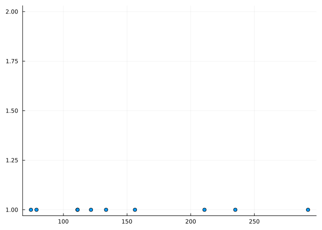

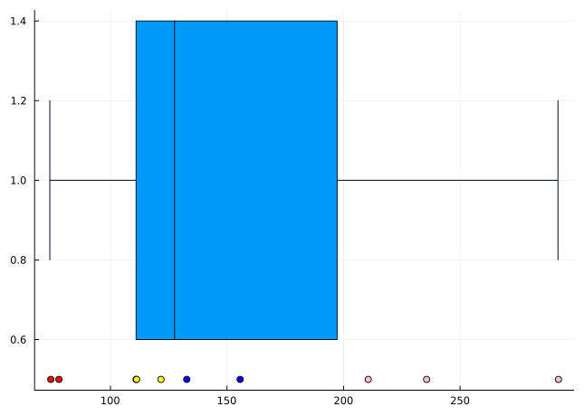

Figure 2.1: The `whale` data summarized with a dot plot on the left and a box plot and accompanying dot plot on the right.

A [histogram](https://en.wikipedia.org/wiki/Histogram) is a another graphic well suited for displaying large data sets. It presents an illustration of what values are seen and also how prevalent that size value is. It does this by selecting a number of “bins” over the range of the data and counting the number of values in that bin, similar to what happens in a stem-and-leaf plot. This number is then represented using a bar with the property that that *area* of the bar is *proportional* to the frequency of data being in that bin. This proportion may just represent the count (if all the bins have the same length), or may be scaled so the total area is $1$ (as these graphics suggest the shape of the underlying probability density function, which has total area $1$). The `histogram` function in `StatsPlots` offers still more means to scale the bars; adjustments specified through the `normalize` argument.

```julia
p1 = histogram(whale; bins = 5, legend=false)

dotplot!(p1, jitter(whale), 1/5 .+ zero.(whale), markersize=10);
```

This graphic is illustrated in Figure 2.2. To make it, we adjusted the default number of bins through the `bins` argument, and added a dotplot with somewhat larger dots, to illustrate the data being counted. The height of each bar should reflect the number of data points within the bin associated to the bar.

Histograms are great for seeing the center of the data (the balancing point of the graphic), the spread, and the shape. However, when the are many bins, the graphic gets busy. The key information being conveyed is the general shape of the top of each bar, not the vertical lines producing the bar. The `stephist` function avoids these lines, though the density plot is a more widely used alternative.

A density plot also illustrates the distribution of values in a data set along with how they cluster, however, it smooths out the binning process. Density plots are scaled to have area $1$, as they will be seen to suggest the shape of a probability density function. In Figure 2.2 we create a density plot overlaid on a histogram, which is normalized to have area $1$:

```julia
p2 = stephist(whale; bins=5, normalize=:pdf, alpha=0.75, legend=false)

density!(p2, whale; linewidth=5);
```

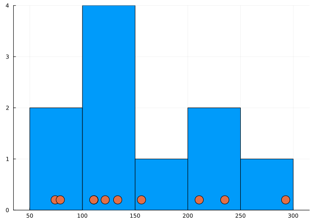

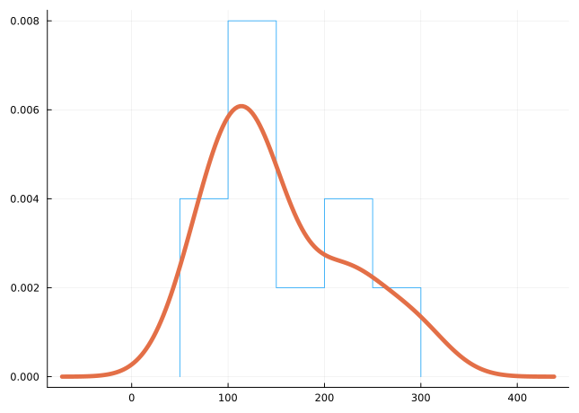

Figure 2.2: The `whale` data summarized with a histogram on the left and a density plot on the right.

A *quantile-normal* plot is a graphic to assess if a data set comes from a *normal distribution*, a reference bell-shaped distribution. The graphic is a *scatter plot* of a quantile of the data set with a corresponding quantile of the reference distribution.

- If the data set has a roughly bell-shaped distribution with “typical” tails, then the dots will mostly fall on a straight line;
- if the data set is skewed one edge will deviate from the line;
- if the data set is symmetric, but has long tails these will show a deviations in both edges of the line.

The `qqnorm` function produces Figure 2.3:

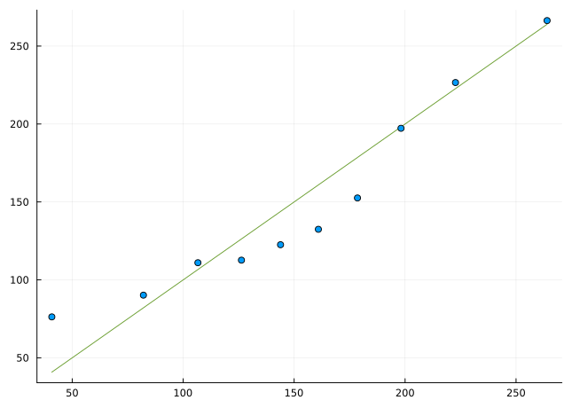

Figure 2.3: A quantile-normal plot of the `whale` data

```julia
qqnorm(whale; legend=false)
```

[^1]: For some cases, where `show` takes too much horizontal space, `permutedims` is used for a similar purpose, as it may elide some values.
[^2]: The parentheses for constructing tuples with 2 or more elements are technically optional, a fact that is useful for bundling different outputs into one
[^3]: The output of the following command is displayed as a tuple, as the commas used create the tuple, even if not enclosed in parentheses.
[^4]: The `var` implementation is via a *string macro*, and is documented through `@var_str`.
[^5]: In `Julia` there are options to have offsets for indexing, e.g. `OffsetArrays` that allow for other access patterns, such as would be useful for zero-based indexing.
[^6]: This example uses the `colon` operator to produce a range of values between it two arguments with increment of $1$.
[^7]: Arrays can be $n$ dimensional, so there may be $1$ or more index to specify
[^8]: Though `:` does, as it is a function, not a keywoard.
[^9]: The `:` *copies* on the right-hand side, but does in-place assignment on the left-hand side
[^10]: The `DataFrames` package is almost always utilized, as it provides a fundamental type to work with tabular data, the data frame. With data frames, the `allowmissing!` function is used, as well, for this task.
[^11]: The `allowmissing` function creates a union type with `Missing` in addition to the original data type. It some printouts, a `?` is appended to the type name to indicate this addition.
[^12]: Also the `@.` *macro* can automatically broadcast all operations.
[^13]: The colon operator `a:b` returns an iterator to produce “`a`, `a+1`, …, `b`”.
[^14]: The expression `s^i` just calls `repeat(s, i)`, for these types.
[^15]: These are illustrated in the `stemplot` function defined later.
[^16]: There are also Demi (3oz), short (8oz), and Trenta (31oz).
[^17]: Different date formats are possible, see `?DateFormat` for details.
[^18]: Tuples and vectors are at times interchangeable, but tuples do not have the associated algebraic operations defined for them, as they need not be homogeneous. With data frames, they are treated quite differently.
[^19]: To extend the `mad` function from `StatsBase` requires the extra step of *importing* that function *or* qualifying it with its module, as in `StatsBase.mad(...) = ...`.
[^20]: Stem-and-leaf plots are very useful for organizing data by hand, but better graphics can be used to illustrate data and its distribution on the computer.